# Analysis for the Stress and Honesty project

Ana Martinovici

2023-02-02

This file includes the analysis for “The effect of acute stress on dishonesty: the moderating role of moral default” (Sebastian P.H. Speer, Ana Martinovici, Ale Smidts, Maarten A.S. Boksem).

```r
load(here::here("data.RData"))
source(here::here("f_aux_functions.R"))
choice_pars <- c("gamma_00", "gamma_std_cheat", "gamma_stress", "gamma_std_cheat_stress")

n_chains <- 10
n_iter   <- 10000
```

# 1 Data summaries

We have 120 participants.

Gender split:

| Gender | n |
| --- | --- |
| Female | 62 |
| Male | 58 |

Age (values rounded to 2 decimals): mean = 20.6 and SD = 2.28.

Each participant completes the same number of tasks, see that the min and max number of tasks per participant are equal:

```r
knitr::kable(part_and_task_info %>%
            group_by(participant_ID) %>%
            summarise(n_tasks_per_i = n()) %>%
            summarise(min_n_tasks = min(n_tasks_per_i),
                    max_n_tasks = max(n_tasks_per_i)))
```

| min_n_tasks | max_n_tasks |
| --- | --- |
| 144 | 144 |

Not all tasks provide an opportunity to cheat. For some tasks, participants had to use a mouse to indicate the differences between pictures, so there was no opportunity to say “Yes, I found all 3 differences” without showing them. All participants complete the same number of **click tasks**, see that the min and max number of click tasks are equal:

```r
knitr::kable(part_and_task_info %>%
            filter(type_of_task == "click") %>%
            group_by(participant_ID) %>%
            summarise(n_tasks_per_i = n()) %>%
            summarise(min_n_tasks = min(n_tasks_per_i),
                    max_n_tasks = max(n_tasks_per_i)))
```

| min_n_tasks | max_n_tasks |
| --- | --- |
| 12 | 12 |

For click trials, each participant had exactly 6 normal trials (reward of 5 cents), 3 hard trials (reward of 20 cents), and 3 very hard trials (reward of 40 cents):

```r
knitr::kable(part_and_task_info %>%
            filter(type_of_task == "click") %>%
            group_by(participant_ID,
                   reward) %>%
            summarise(n_tasks = n()) %>%
            ungroup() %>%
            group_by(reward) %>%
            summarise(min_n_tasks = min(n_tasks),
                    max_n_tasks = max(n_tasks)))
```

| reward | min_n_tasks | max_n_tasks |
| --- | --- | --- |
| 0.05 | 6 | 6 |
| 0.20 | 3 | 3 |
| 0.40 | 3 | 3 |

For no-click tasks, the split between trials with 1, 2, or 3 differences is:

```r
knitr::kable(part_and_task_info %>%
            filter(type_of_task == "noclick") %>%
            group_by(n_differences) %>%
            summarise(n_tasks = n()) %>%
            ungroup() %>%
            mutate(perc_tasks = n_tasks / sum(n_tasks)),
         digits = 2)
```

| n_differences | n_tasks | perc_tasks |
| --- | --- | --- |
| 1 | 3975 | 0.25 |
| 2 | 3968 | 0.25 |
| 3 | 7897 | 0.50 |

For no-click tasks, the split by reward:

```r
knitr::kable(part_and_task_info %>%
            filter(type_of_task == "noclick") %>%
            group_by(reward) %>%
            summarise(n_tasks = n()) %>%
            ungroup() %>%
            mutate(perc_tasks = n_tasks / sum(n_tasks)),
         digits = 2)
```

| reward | n_tasks | perc_tasks |
| --- | --- | --- |
| 0.05 | 7089 | 0.45 |
| 0.20 | 4857 | 0.31 |
| 0.40 | 3894 | 0.25 |

For no-click trials with three differences, the split by reward is:

```r
knitr::kable(part_and_task_info %>%
            filter(type_of_task == "noclick") %>%
            filter(n_differences == 3) %>%
            group_by(reward) %>%
            summarise(n_tasks = n()) %>%
            ungroup() %>%
            mutate(perc_tasks = n_tasks / sum(n_tasks)),
         digits = 2)
```

| reward | n_tasks | perc_tasks |
| --- | --- | --- |
| 0.05 | 6967 | 0.88 |
| 0.20 | 904 | 0.11 |
| 0.40 | 26 | 0.00 |

For trials with 1 or 2 differences, the split between normal and hard or very hard is:

```r
knitr::kable(part_and_task_info %>%
            filter(type_of_task == "noclick") %>%
            filter(n_differences %in% c(1, 2)) %>%
            mutate(difficulty = if_else(reward %in% c(0.20, 0.40), "hard or very hard", "normal")) %>%
            group_by(difficulty) %>%
            summarise(n_tasks = n()) %>%
            ungroup() %>%
            mutate(perc_tasks = n_tasks / sum(n_tasks)),
         digits = 2)
```

| difficulty | n_tasks | perc_tasks |
| --- | --- | --- |
| hard or very hard | 7821 | 0.98 |
| normal | 122 | 0.02 |

# 2 Results

## 2.1 Plot % cheating in first half

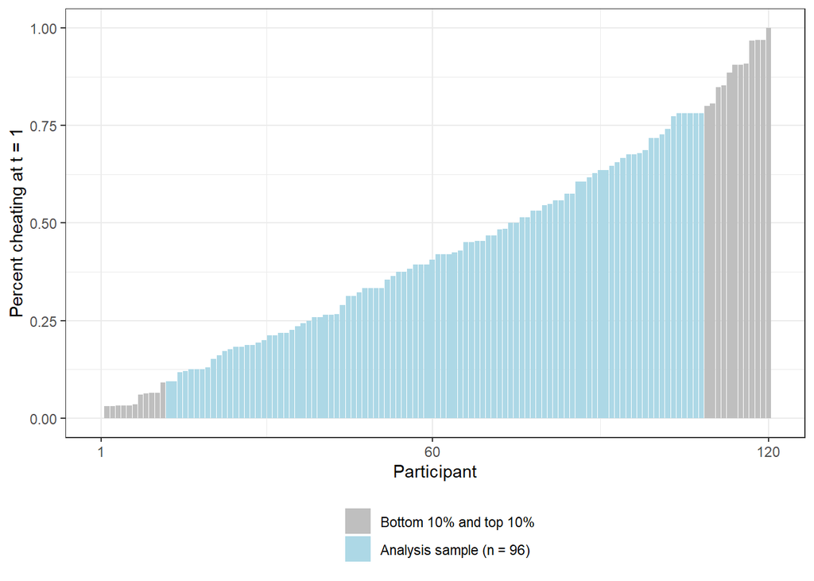

```r
df_plot <- part_and_task_info %>%
    filter(type_of_task == "noclick") %>%
    filter(n_differences %in% c(1, 2)) %>%
    filter(reward %in% c(0.20, 0.40)) %>%
    filter(part_response %in% c("No, did not find 3 diffs", "Yes, found 3 diffs")) %>%
    filter(is_in_second_half == 0)

df_plot <- df_plot %>%
    group_by(participant_ID) %>%
    summarise(n_tasks = n(),
            n_cheated = sum(part_response == "Yes, found 3 diffs"),
            perc_cheating = n_cheated / n_tasks) %>%
    ungroup()

mean_cheating <- mean(df_plot$perc_cheating)
sd_cheating   <- sd(df_plot$perc_cheating)

df_plot <- df_plot %>%
    mutate(std_perc_cheating = (perc_cheating - mean_cheating) / sd_cheating)

bottom_10perc <- quantile(df_plot$std_perc_cheating, probs = c(0.10))
top_10perc    <- quantile(df_plot$std_perc_cheating, probs = c(0.90))

df_plot <- df_plot %>%
    mutate(is_between_bottom_top_10perc =
            (std_perc_cheating >= bottom_10perc)*
            (std_perc_cheating <= top_10perc))

df_plot <- df_plot %>%
    arrange(perc_cheating) %>%
    mutate(cheat_number = row_number()) %>%
    mutate(f_fill = factor(is_between_bottom_top_10perc,
                     levels = c(0, 1),
                     labels = c("bottom", "middle")))

figure2 <- df_plot %>%
    ggplot(aes(x = cheat_number, y = perc_cheating)) +
    geom_col(aes(fill = f_fill), width = 0.9) +
    theme_bw() +
    ylab("Percent cheating at t = 1") +
    xlab("Participant") +
    scale_x_continuous(breaks = c(1, 60, 120)) +
    scale_fill_manual("",
                breaks = c("bottom", "middle"),
                values = c("middle" = "lightblue",
                         "bottom" = "grey75"),
                labels = c("bottom" = "Bottom 10% and top 10%",
                         "middle" = paste0("Analysis sample (n = ",
                                    nrow(df_plot %>%
                                            filter(is_between_bottom_top_10perc == 1)),
                                    ")"))) +
    guides(fill = guide_legend(nrow = 2)) +
    theme(legend.position = "bottom")

figure2
```

The average percent cheating for the bottom 10% and top 10% is:

```r
knitr::kable(df_plot %>%
            filter(is_between_bottom_top_10perc == 0) %>%
            mutate(group_name = if_else(std_perc_cheating < 0, "bottom_10", "top_10")) %>%
            group_by(group_name) %>%
            summarise(n_obs = n(),
                    mean_perc_cheating = mean(perc_cheating),
                    mean_cheated = round(mean(n_cheated), 0),
                    mean_tasks = round(mean(n_tasks), 0)),
         digits = 2)
```

| group_name | n_obs | mean_perc_cheating | mean_cheated | mean_tasks |
| --- | --- | --- | --- | --- |
| bottom_10 | 12 | 0.04 | 1 | 32 |
| top_10 | 12 | 0.90 | 29 | 32 |

## 2.2 Model estimation results

Exclude participants in the tom 10% and bottom 10%, based on cheating percentile.

```r
WO_top10_bottom10_df <- f_prep_use_tasks(part_info = part_info,
                             part_and_task_info = part_and_task_info,
                             exclusion_C1 = "no_exclusion",
                             exclusion_C2 = "top_bottom_10")
WO_top10_bottom10_stan_data <- f_prep_stan_data(use_tasks = WO_top10_bottom10_df[["use_tasks"]])

WO_top10_bottom10_choice_fit <- sampling(choice_model,
                             data = WO_top10_bottom10_stan_data,
                             chains = n_chains,
                             iter = n_iter,
                             seed = 25,
                             save_warmup = FALSE)
```

Check convergence (Rhat values should be 1):

```r
summary(summary(WO_top10_bottom10_choice_fit)[["summary"]][, "Rhat"])
```

```
##    Min. 1st Qu.  Median    Mean 3rd Qu.    Max.
##       1       1       1       1       1       1
```

Estimation results are:

```r
knitr::kable(f_sum_results(par_names = choice_pars,
                   stan_fit = WO_top10_bottom10_choice_fit),
         digits = c(0, 2, 2, 3, 2, 2))
```

| param_name | post_mean | post_sd | p_value | lower_CI | upper_CI |
| --- | --- | --- | --- | --- | --- |
| gamma_00 | -0.39 | 0.06 | 0.000 | -0.50 | -0.28 |
| gamma_std_cheat | 1.26 | 0.08 | 0.000 | 1.11 | 1.41 |
| gamma_stress | 0.23 | 0.08 | 0.003 | 0.07 | 0.40 |
| gamma_std_cheat_stress | 0.52 | 0.13 | 0.000 | 0.28 | 0.77 |

Interaction plot:

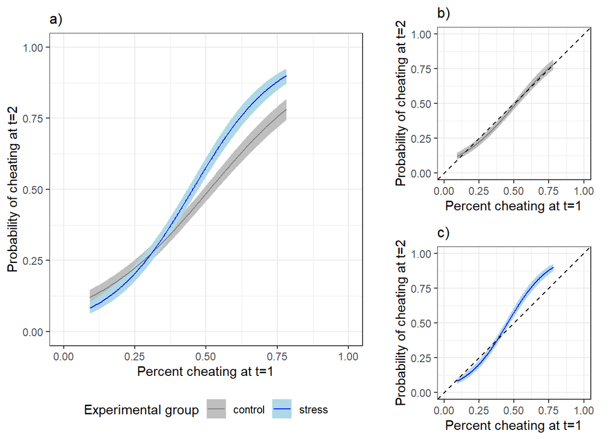

```r
figure3 <- f_plot_interaction_3in1(
    choice_fit = WO_top10_bottom10_choice_fit,
    grid_std_cheating = seq(
        from = floor(min(WO_top10_bottom10_stan_data[["X_cheat_H1"]]) * 100) / 100,
        to = ceiling(max(WO_top10_bottom10_stan_data[["X_cheat_H1"]]) * 100) / 100,
        by = 0.01),
    mean_cheating = mean_cheating,
    sd_cheating = sd_cheating)
```

```r
figure3
```

Mean and SD cheating, by group and block:

```r
knitr::kable(WO_top10_bottom10_df[["use_tasks"]] %>%
            group_by(participant_ID,
                   experimental_cond,
                   study_half_number) %>%
            summarise(perc_cheat = sum(is_cheating) / n()) %>%
            ungroup() %>%
            group_by(experimental_cond,
                   study_half_number) %>%
            summarise(n(),
                    mean(perc_cheat),
                    sd(perc_cheat)),
         digits = 2)
```

```
## can override using the `.groups` argument.
```

| experimental_cond | study_half_number | n() | mean(perc_cheat) | sd(perc_cheat) |
| --- | --- | --- | --- | --- |
| Control | H1 | 52 | 0.44 | 0.20 |
| Control | H2 | 52 | 0.43 | 0.29 |
| Stress | H1 | 44 | 0.39 | 0.20 |
| Stress | H2 | 44 | 0.43 | 0.31 |

Check differences between control and stress in the percent of trials cheated during the first block.

```r
df_plot <- df_plot %>%
    left_join(part_info %>%
                select(participant_ID,
                     experimental_cond),
            by = "participant_ID")

aux_check <- lm(perc_cheating ~ experimental_cond,
            data = df_plot %>%
                filter(is_between_bottom_top_10perc == 1))
summary(aux_check)
```

```
##
## Call:
## lm(formula = perc_cheating ~ experimental_cond, data = df_plot %>%
##     filter(is_between_bottom_top_10perc == 1))
##
## Residuals:
##      Min       1Q   Median       3Q      Max
## -0.31738 -0.19049 -0.01556  0.16531  0.38701
##
## Coefficients:
##                         Estimate Std. Error t value Pr(>|t|)
## (Intercept)              0.43859    0.02796  15.684   <2e-16 ***
## experimental_condStress -0.04435    0.04131  -1.074    0.286
## ---
## Signif. codes:  0 '***' 0.001 '**' 0.01 '*' 0.05 '.' 0.1 ' ' 1
##
## Residual standard error: 0.2017 on 94 degrees of freedom
## Multiple R-squared:  0.01212,    Adjusted R-squared:  0.001607
## F-statistic: 1.153 on 1 and 94 DF,  p-value: 0.2857
```

# 3 Results in Appendix

## 3.1 All participants (n = 120)

```r
allN_df <- f_prep_use_tasks(part_info = part_info,
                    part_and_task_info = part_and_task_info,
                    exclusion_C1 = "no_exclusion",
                    exclusion_C2 = "no_exclusion")
allN_stan_data <- f_prep_stan_data(use_tasks = allN_df[["use_tasks"]])

allN_choice_fit <- sampling(choice_model,
                    data = allN_stan_data,
                    chains = n_chains,
                    iter = n_iter,
                    seed = 25,
                    save_warmup = FALSE)
```

Check convergence (Rhat values should be 1):

```r
summary(summary(allN_choice_fit)[["summary"]][, "Rhat"])
```

```
##    Min. 1st Qu.  Median    Mean 3rd Qu.    Max.
##       1       1       1       1       1       1
```

Estimation results are:

```r
knitr::kable(f_sum_results(par_names = choice_pars,
                   stan_fit = allN_choice_fit),
         digits = c(0, 2, 2, 3, 2, 2))
```

| param_name | post_mean | post_sd | p_value | lower_CI | upper_CI |
| --- | --- | --- | --- | --- | --- |
| gamma_00 | -0.43 | 0.05 | 0.000 | -0.53 | -0.32 |
| gamma_std_cheat | 1.36 | 0.07 | 0.000 | 1.23 | 1.50 |
| gamma_stress | 0.20 | 0.08 | 0.005 | 0.05 | 0.36 |
| gamma_std_cheat_stress | 0.18 | 0.10 | 0.028 | -0.01 | 0.37 |

Mean and SD cheating, by group and block:

```r
knitr::kable(allN_df[["use_tasks"]] %>%
            group_by(participant_ID,
                   experimental_cond,
                   study_half_number) %>%
            summarise(perc_cheat = sum(is_cheating) / n()) %>%
            ungroup() %>%
            group_by(experimental_cond,
                   study_half_number) %>%
            summarise(n(),
                    mean(perc_cheat),
                    sd(perc_cheat)),
         digits = 2)
```

```
## can override using the `.groups` argument.
```

| experimental_cond | study_half_number | n() | mean(perc_cheat) | sd(perc_cheat) |
| --- | --- | --- | --- | --- |
| Control | H1 | 60 | 0.43 | 0.25 |
| Control | H2 | 60 | 0.42 | 0.31 |
| Stress | H1 | 60 | 0.43 | 0.28 |
| Stress | H2 | 60 | 0.45 | 0.34 |

Check differences between control and stress in the percent of trials cheated during the first block.

```r
aux_check <- lm(perc_cheating ~ experimental_cond,
            data = df_plot)
summary(aux_check)
```

```
##
## Call:
## lm(formula = perc_cheating ~ experimental_cond, data = df_plot)
##
## Residuals:
##      Min       1Q   Median       3Q      Max
## -0.42647 -0.22290 -0.01919  0.20437  0.56801
##
## Coefficients:
##                          Estimate Std. Error t value Pr(>|t|)
## (Intercept)              0.431991   0.034427  12.548   <2e-16 ***
## experimental_condStress -0.005522   0.048687  -0.113     0.91
## ---
## Signif. codes:  0 '***' 0.001 '**' 0.01 '*' 0.05 '.' 0.1 ' ' 1
##
## Residual standard error: 0.2667 on 118 degrees of freedom
## Multiple R-squared:  0.000109,   Adjusted R-squared:  -0.008365
## F-statistic: 0.01286 on 1 and 118 DF,  p-value: 0.9099
```

## 3.2 Exclude top 5% and bottom 5%

```r
WO_top5_bottom5_df <- f_prep_use_tasks(part_info = part_info,
                           part_and_task_info = part_and_task_info,
                           exclusion_C1 = "no_exclusion",
                           exclusion_C2 = "top_bottom_5")
WO_top5_bottom5_stan_data <- f_prep_stan_data(use_tasks = WO_top5_bottom5_df[["use_tasks"]])

WO_top5_bottom5_choice_fit <- sampling(choice_model,
                           data = WO_top5_bottom5_stan_data,
                           chains = n_chains,
                           iter = n_iter,
                           seed = 25,
                           save_warmup = FALSE)
```

Check convergence (Rhat values should be 1):

```r
summary(summary(WO_top5_bottom5_choice_fit)[["summary"]][, "Rhat"])
```

```
##    Min. 1st Qu.  Median    Mean 3rd Qu.    Max.
##       1       1       1       1       1       1
```

Estimation results are:

```r
knitr::kable(f_sum_results(par_names = choice_pars,
                   stan_fit = WO_top5_bottom5_choice_fit),
         digits = c(0, 2, 2, 3, 2, 2))
```

| param_name | post_mean | post_sd | p_value | lower_CI | upper_CI |
| --- | --- | --- | --- | --- | --- |
| gamma_00 | -0.43 | 0.05 | 0.000 | -0.54 | -0.33 |
| gamma_std_cheat | 1.31 | 0.07 | 0.000 | 1.17 | 1.45 |
| gamma_stress | 0.22 | 0.08 | 0.002 | 0.07 | 0.38 |
| gamma_std_cheat_stress | 0.18 | 0.10 | 0.039 | -0.02 | 0.38 |

Mean and SD cheating, by group and block:

```r
knitr::kable(WO_top5_bottom5_df[["use_tasks"]] %>%
            group_by(participant_ID,
                   experimental_cond,
                   study_half_number) %>%
            summarise(perc_cheat = sum(is_cheating) / n()) %>%
            ungroup() %>%
            group_by(experimental_cond,
                   study_half_number) %>%
            summarise(n(),
                    mean(perc_cheat),
                    sd(perc_cheat)),
         digits = 2)
```

```
## can override using the `.groups` argument.
```

| experimental_cond | study_half_number | n() | mean(perc_cheat) | sd(perc_cheat) |
| --- | --- | --- | --- | --- |
| Control | H1 | 57 | 0.42 | 0.23 |
| Control | H2 | 57 | 0.40 | 0.30 |
| Stress | H1 | 52 | 0.43 | 0.25 |
| Stress | H2 | 52 | 0.46 | 0.32 |

Check differences between control and stress in the percent of trials cheated during the first block.

```r
aux_df <- df_plot %>%
    inner_join(WO_top5_bottom5_df[["use_participants"]] %>%
                select(participant_ID),
             by = c("participant_ID"))

aux_check <- lm(perc_cheating ~ experimental_cond,
            data = aux_df)
summary(aux_check)
```

```
##
## Call:
## lm(formula = perc_cheating ~ experimental_cond, data = aux_df)
##
## Residuals:
##      Min       1Q   Median       3Q      Max
## -0.38514 -0.20087 -0.01337  0.18644  0.47128
##
## Coefficients:
##                         Estimate Std. Error t value Pr(>|t|)
## (Intercept)              0.41962    0.03131  13.402   <2e-16 ***
## experimental_condStress  0.01535    0.04533   0.339    0.736
## ---
## Signif. codes:  0 '***' 0.001 '**' 0.01 '*' 0.05 '.' 0.1 ' ' 1
##
## Residual standard error: 0.2364 on 107 degrees of freedom
## Multiple R-squared:  0.00107,    Adjusted R-squared:  -0.008266
## F-statistic: 0.1146 on 1 and 107 DF,  p-value: 0.7356
```

## 3.3 Exclude top 15% and bottom 15%

```r
WO_top15_bottom15_df <- f_prep_use_tasks(part_info = part_info,
                             part_and_task_info = part_and_task_info,
                             exclusion_C1 = "no_exclusion",
                             exclusion_C2 = "top_bottom_15")
WO_top15_bottom15_stan_data <- f_prep_stan_data(use_tasks = WO_top15_bottom15_df[["use_tasks"]])

WO_top15_bottom15_choice_fit <- sampling(choice_model,
                             data = WO_top15_bottom15_stan_data,
                             chains = 2,
                             iter = 2000,
                             seed = 25,
                             save_warmup = FALSE)
```

Check convergence (Rhat values should be 1):

```r
summary(summary(WO_top15_bottom15_choice_fit)[["summary"]][, "Rhat"])
```

```
##    Min. 1st Qu.  Median    Mean 3rd Qu.    Max.
##  0.9995  0.9996  0.9998  0.9998  0.9999  1.0002
```

Estimation results are:

```r
knitr::kable(f_sum_results(par_names = choice_pars,
                   stan_fit = WO_top15_bottom15_choice_fit),
         digits = c(0, 2, 2, 3, 2, 2))
```

| param_name | post_mean | post_sd | p_value | lower_CI | upper_CI |
| --- | --- | --- | --- | --- | --- |
| gamma_00 | -0.42 | 0.05 | 0 | -0.53 | -0.31 |
| gamma_std_cheat | 1.12 | 0.09 | 0 | 0.94 | 1.29 |
| gamma_stress | 0.27 | 0.08 | 0 | 0.11 | 0.43 |
| gamma_std_cheat_stress | 0.65 | 0.14 | 0 | 0.37 | 0.93 |

Mean and SD cheating, by group and block:

```r
knitr::kable(WO_top15_bottom15_df[["use_tasks"]] %>%
            group_by(participant_ID,
                   experimental_cond,
                   study_half_number) %>%
            summarise(perc_cheat = sum(is_cheating) / n()) %>%
            ungroup() %>%
            group_by(experimental_cond,
                   study_half_number) %>%
            summarise(n(),
                    mean(perc_cheat),
                    sd(perc_cheat)),
         digits = 2)
```

```
## can override using the `.groups` argument.
```

| experimental_cond | study_half_number | n() | mean(perc_cheat) | sd(perc_cheat) |
| --- | --- | --- | --- | --- |
| Control | H1 | 46 | 0.41 | 0.18 |
| Control | H2 | 46 | 0.39 | 0.25 |
| Stress | H1 | 40 | 0.41 | 0.18 |
| Stress | H2 | 40 | 0.44 | 0.30 |

Check differences between control and stress in the percent of trials cheated during the first block.

```r
aux_df <- df_plot %>%
    inner_join(WO_top15_bottom15_df[["use_participants"]] %>%
                select(participant_ID),
             by = c("participant_ID"))

aux_check <- lm(perc_cheating ~ experimental_cond,
            data = aux_df)
summary(aux_check)
```

```
##
## Call:
## lm(formula = perc_cheating ~ experimental_cond, data = aux_df)
##
## Residuals:
##      Min       1Q   Median       3Q      Max
## -0.28340 -0.15638 -0.00736  0.14115  0.33543
##
## Coefficients:
##                          Estimate Std. Error t value Pr(>|t|)
## (Intercept)              0.408399   0.026359  15.494   <2e-16 ***
## experimental_condStress -0.001895   0.038650  -0.049    0.961
## ---
## Signif. codes:  0 '***' 0.001 '**' 0.01 '*' 0.05 '.' 0.1 ' ' 1
##
## Residual standard error: 0.1788 on 84 degrees of freedom
## Multiple R-squared:  2.862e-05,  Adjusted R-squared:  -0.01188
## F-statistic: 0.002404 on 1 and 84 DF,  p-value: 0.961
```

## 3.4 Hand taken out

```r
WO_Hand_out_df <- f_prep_use_tasks(part_info = part_info,
                         part_and_task_info = part_and_task_info,
                         exclusion_C1 = "Hand_out",
                         exclusion_C2 = "no_exclusion")
```

```
## you exclude participants who take the hand out
```

```r
WO_Hand_out_stan_data <- f_prep_stan_data(use_tasks = WO_Hand_out_df[["use_tasks"]])

WO_Hand_out_choice_fit <- sampling(choice_model,
                         data = WO_Hand_out_stan_data,
                         chains = n_chains,
                         iter = n_iter,
                         seed = 25,
                         save_warmup = FALSE)
```

Check convergence (Rhat values should be 1):

```r
summary(summary(WO_Hand_out_choice_fit)[["summary"]][, "Rhat"])
```

```
##    Min. 1st Qu.  Median    Mean 3rd Qu.    Max.
##       1       1       1       1       1       1
```

Estimation results are:

```r
knitr::kable(f_sum_results(par_names = choice_pars,
                   stan_fit = WO_Hand_out_choice_fit),
         digits = c(0, 2, 2, 3, 2, 2))
```

| param_name | post_mean | post_sd | p_value | lower_CI | upper_CI |
| --- | --- | --- | --- | --- | --- |
| gamma_00 | -0.42 | 0.05 | 0.000 | -0.53 | -0.32 |
| gamma_std_cheat | 1.36 | 0.07 | 0.000 | 1.23 | 1.50 |
| gamma_stress | 0.23 | 0.08 | 0.002 | 0.08 | 0.39 |
| gamma_std_cheat_stress | 0.17 | 0.10 | 0.041 | -0.02 | 0.37 |

Mean and SD cheating, by group and block:

```r
knitr::kable(WO_Hand_out_df[["use_tasks"]] %>%
            group_by(participant_ID,
                   experimental_cond,
                   study_half_number) %>%
            summarise(perc_cheat = sum(is_cheating) / n()) %>%
            ungroup() %>%
            group_by(experimental_cond,
                   study_half_number) %>%
            summarise(n(),
                    mean(perc_cheat),
                    sd(perc_cheat)),
         digits = 2)
```

```
## can override using the `.groups` argument.
```

| experimental_cond | study_half_number | n() | mean(perc_cheat) | sd(perc_cheat) |
| --- | --- | --- | --- | --- |
| Control | H1 | 60 | 0.43 | 0.25 |
| Control | H2 | 60 | 0.42 | 0.31 |
| Stress | H1 | 54 | 0.43 | 0.28 |
| Stress | H2 | 54 | 0.46 | 0.35 |

Check differences between control and stress in the percent of trials cheated during the first block.

```r
aux_df <- df_plot %>%
    inner_join(WO_Hand_out_df[["use_participants"]] %>%
                select(participant_ID),
             by = c("participant_ID"))

aux_check <- lm(perc_cheating ~ experimental_cond,
            data = aux_df)
summary(aux_check)
```

```
##
## Call:
## lm(formula = perc_cheating ~ experimental_cond, data = aux_df)
##
## Residuals:
##     Min      1Q  Median      3Q     Max
## -0.4294 -0.2192 -0.0306  0.2044  0.5680
##
## Coefficients:
##                          Estimate Std. Error t value Pr(>|t|)
## (Intercept)              0.431991   0.034421  12.550   <2e-16 ***
## experimental_condStress -0.002595   0.050012  -0.052    0.959
## ---
## Signif. codes:  0 '***' 0.001 '**' 0.01 '*' 0.05 '.' 0.1 ' ' 1
##
## Residual standard error: 0.2666 on 112 degrees of freedom
## Multiple R-squared:  2.403e-05,  Adjusted R-squared:  -0.008904
## F-statistic: 0.002692 on 1 and 112 DF,  p-value: 0.9587
```

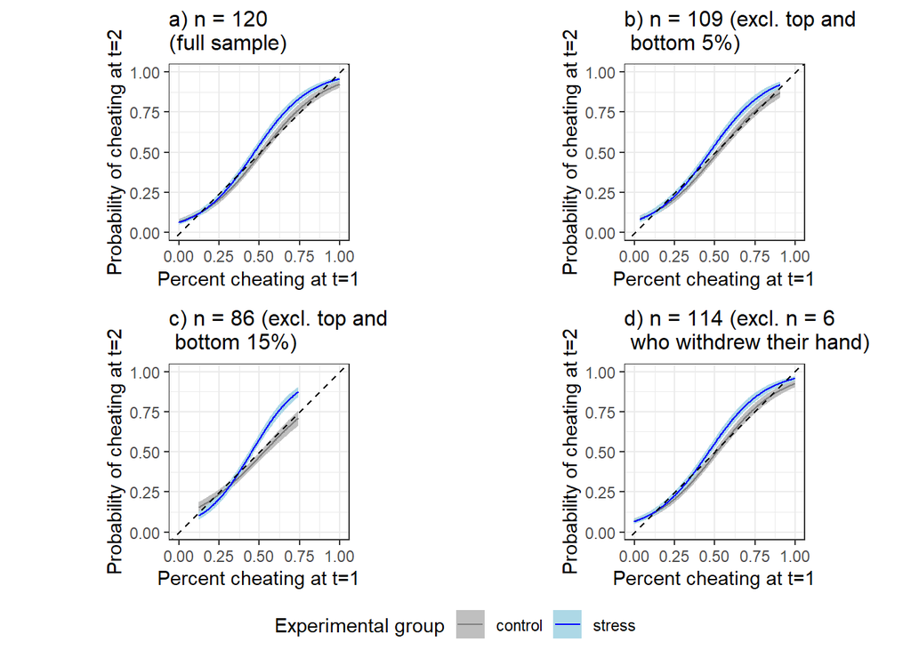

```r
plot_allN <- f_plot_interaction_single(
    choice_fit = allN_choice_fit,
    grid_std_cheating = seq(
        from = floor(min(allN_stan_data[["X_cheat_H1"]]) * 100) / 100,
        to = ceiling(max(allN_stan_data[["X_cheat_H1"]]) * 100) / 100,
        by = 0.01),
    mean_cheating = mean_cheating,
    sd_cheating = sd_cheating)

plot_WO_top5_bottom5 <- f_plot_interaction_single(
    choice_fit = WO_top5_bottom5_choice_fit,
    grid_std_cheating = seq(
        from = floor(min(WO_top5_bottom5_stan_data[["X_cheat_H1"]]) * 100) / 100,
        to = ceiling(max(WO_top5_bottom5_stan_data[["X_cheat_H1"]]) * 100) / 100,
        by = 0.01),
    mean_cheating = mean_cheating,
    sd_cheating = sd_cheating)

plot_WO_top15_bottom15 <- f_plot_interaction_single(
    choice_fit = WO_top15_bottom15_choice_fit,
    grid_std_cheating = seq(
        from = floor(min(WO_top15_bottom15_stan_data[["X_cheat_H1"]]) * 100) / 100,
        to = ceiling(max(WO_top15_bottom15_stan_data[["X_cheat_H1"]]) * 100) / 100,
        by = 0.01),
    mean_cheating = mean_cheating,
    sd_cheating = sd_cheating)

plot_WO_hand_out <- f_plot_interaction_single(
    choice_fit = WO_Hand_out_choice_fit,
    grid_std_cheating = seq(
        from = floor(min(WO_Hand_out_stan_data[["X_cheat_H1"]]) * 100) / 100,
        to = ceiling(max(WO_Hand_out_stan_data[["X_cheat_H1"]]) * 100) / 100,
        by = 0.01),
    mean_cheating = mean_cheating,
    sd_cheating = sd_cheating)

plot_allN <- plot_allN +
    labs(title = paste0("a) n = ", nrow(allN_df[["use_participants"]]),
                  "\n(full sample)"))
plot_WO_top5_bottom5 <- plot_WO_top5_bottom5 +
    labs(title = paste0("b) n = ", nrow(WO_top5_bottom5_df[["use_participants"]]),
                  " (excl. top and \n bottom 5%)"))
plot_WO_top15_bottom15 <- plot_WO_top15_bottom15 +
    labs(title = paste0("c) n = ", nrow(WO_top15_bottom15_df[["use_participants"]]),
                  " (excl. top and \n bottom 15%)"))
plot_WO_hand_out <- plot_WO_hand_out +
    labs(title = paste0("d) n = ", nrow(WO_Hand_out_df[["use_participants"]]),
                  " (excl. n = 6 \n who withdrew their hand)"))

SM_plot <- ggpubr::ggarrange(plot_allN,
                     plot_WO_top5_bottom5,
                     plot_WO_top15_bottom15,
                     plot_WO_hand_out,
                     nrow = 2,
                     ncol = 2,
                     common.legend = TRUE,
                     legend = "bottom")
SM_plot
```

# 4 Info about R packages